# HomeWork6

Mahsa Naeimi

2023-05-24

### **Section 1: Improving analysis code by writing functions**

#### B.

```r
# Can you improve this analysis code?
library(bio3d)
# s1 <- read.pdb("4AKE")  # kinase with drug
# s2 <- read.pdb("1AKE")  # kinase no drug
# s3 <- read.pdb("1E4Y")  # kinase with drug
# s1.chainA <- trim.pdb(s1, chain="A", elety="CA")
# s2.chainA <- trim.pdb(s2, chain="A", elety="CA")
# s3.chainA <- trim.pdb(s1, chain="A", elety="CA")
# s1.b <- s1.chainA$atom$b
# s2.b <- s2.chainA$atom$b
# s3.b <- s3.chainA$atom$b
# plotb3(s1.b, sse=s1.chainA, typ="l", ylab="Bfactor")
# plotb3(s2.b, sse=s2.chainA, typ="l", ylab="Bfactor")
# plotb3(s3.b, sse=s3.chainA, typ="l", ylab="Bfactor")

#improving copy paste issues:
s1 <- read.pdb("4AKE")  # kinase with drug
```

```
##   Note: Accessing on-line PDB file
```

```r
s2 <- read.pdb("1AKE")  # kinase no drug
```

```
##   Note: Accessing on-line PDB file
##    PDB has ALT records, taking A only, rm.alt=TRUE
```

```r
s3 <- read.pdb("1E4Y")  # kinase with drug
```

```
##   Note: Accessing on-line PDB file
```

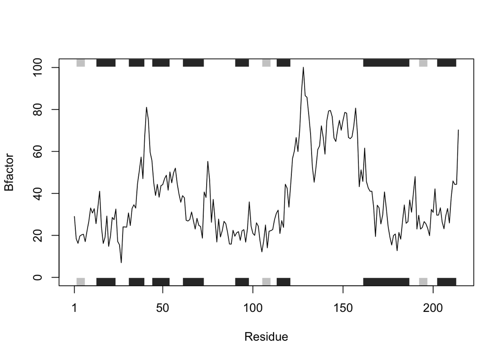

```r
s1.chainA <- trim.pdb(s1, chain="A", elety="CA")
s2.chainA <- trim.pdb(s2, chain="A", elety="CA")
s3.chainA <- trim.pdb(s3, chain="A", elety="CA")

s1.b <- s1.chainA$atom$b
s2.b <- s2.chainA$atom$b
s3.b <- s3.chainA$atom$b

plotb3(s1.b, sse = s1.chainA, typ = "l", ylab = "Bfactor")
```

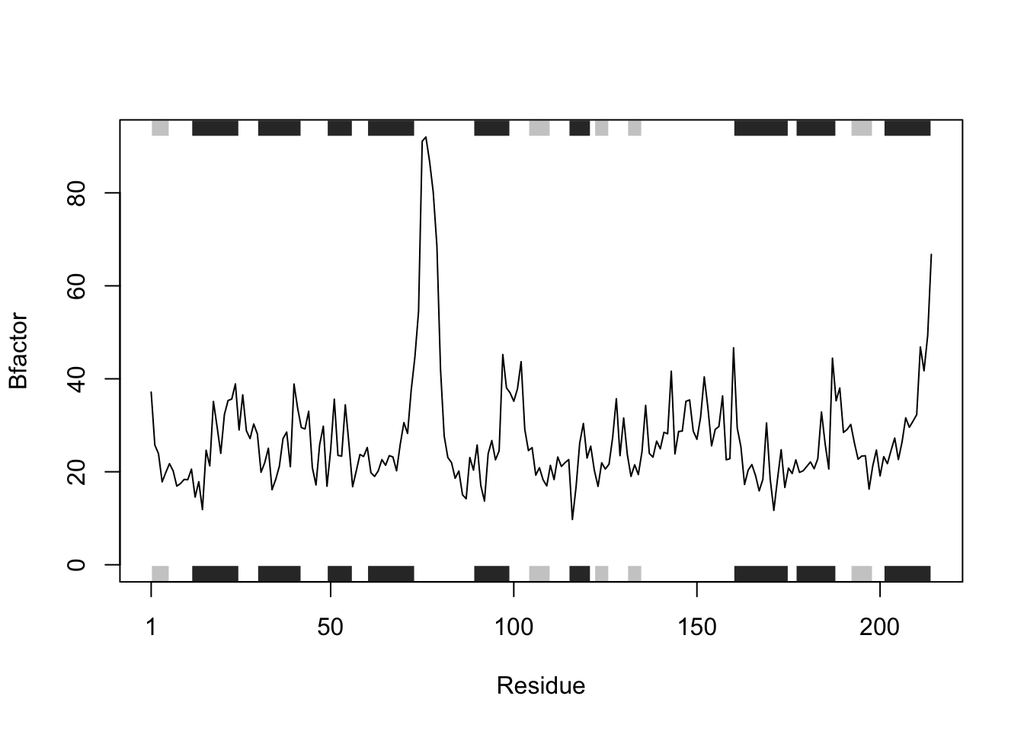

```r
plotb3(s2.b, sse = s2.chainA, typ = "l", ylab = "Bfactor")
```

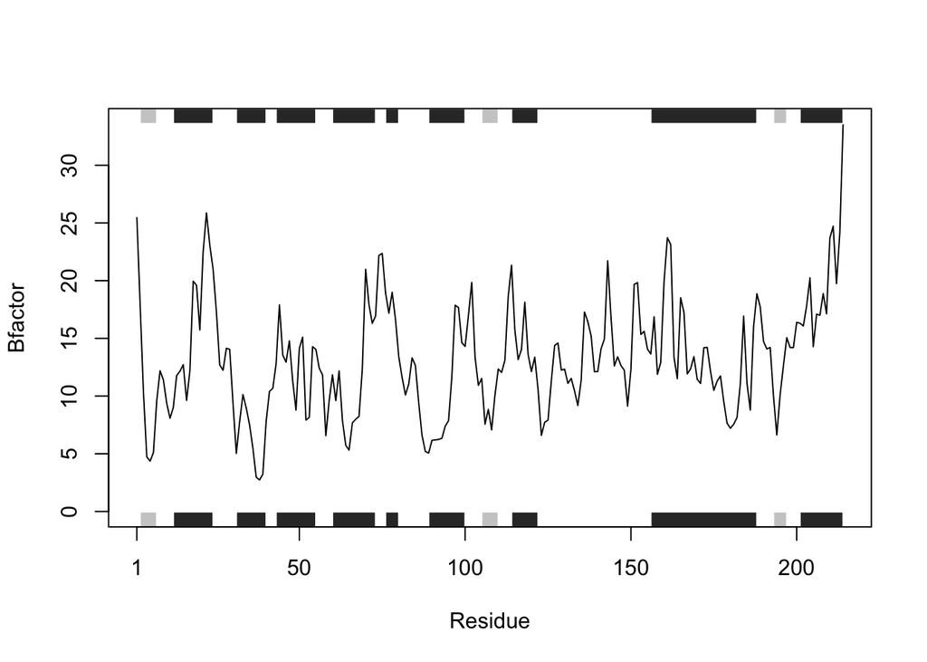

```r
plotb3(s3.b, sse = s3.chainA, typ = "l", ylab = "Bfactor")
```

We want to create a function to be able to visualize protein-drug interactions from PDB data:

```r
pr_dr <- function(file, chain, elmnt, fctr) {
   plot_colors <- c("red", "blue", "green")
     for (i in 1:length(file)) {
  s1 <- read.pdb(file[i])

  s1.chain <- trim.pdb(s1, chain = chain, elety = elmnt)

  atom_df <- s1.chain$atom
   s1.fctr <- atom_df[, fctr]
     if (i == 1) {
    plotb3(s1.fctr, sse = s1.chain, typ = "l", ylab = paste(toupper(fctr), "factor", sep = ""), col = plot_colors[i])
     } else {
    lines(s1.fctr, col = plot_colors[i])
  }
     }
     legend("topright", title = "PDB File Name", file, fill = plot_colors, horiz=TRUE, cex = 0.5, inset = c(0.03, 0.06))
}
```

```r
# Testing the function for theses 3 protein:
files <- c("4AKE", "1AKE", "1E4Y")
chains <- "A"
elements <- "CA"
factors <- "b"

pr_dr(files, chains, elements, factors)
```

```
##   Note: Accessing on-line PDB file
```

```
##   Note: Accessing on-line PDB file
```

```
##    PDB has ALT records, taking A only, rm.alt=TRUE
##   Note: Accessing on-line PDB file
```

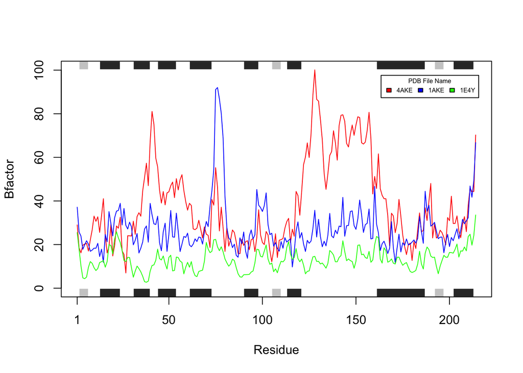

**Q1. What type of object is returned from the read.pdb() function?** This function returns information about the structure of the protein, its building block, and sequence of the protein from PDB

```r
read.pdb("4AKE")
```

```
##   Note: Accessing on-line PDB file
```

```
##
##  Call:  read.pdb(file = "4AKE")
##
##    Total Models#: 1
##      Total Atoms#: 3459,  XYZs#: 10377  Chains#: 2  (values: A B)
##
##      Protein Atoms#: 3312  (residues/Calpha atoms#: 428)
##      Nucleic acid Atoms#: 0  (residues/phosphate atoms#: 0)
##
##      Non-protein/nucleic Atoms#: 147  (residues: 147)
##      Non-protein/nucleic resid values: [ HOH (147) ]
##
##    Protein sequence:
##       MRIILLGAPGAGKGTQAQFIMEKYGIPQISTGDMLRAAVKSGSELGKQAKDIMDAGKLVT
##       DELVIALVKERIAQEDCRNGFLLDGFPRTIPQADAMKEAGINVDYVLEFDVPDELIVDRI
##       VGRRVHAPSGRVYHVKFNPPKVEGKDDVTGEELTTRKDDQEETVRKRLVEYHQMTAPLIG
##       YYSKEAEAGNTKYAKVDGTKPVAEVRADLEKILGMRIILLGAPGA...<cut>...KILG
##
## + attr: atom, xyz, seqres, helix, sheet,
##         calpha, remark, call
```

**Q2. What does the trim.pdb() function do?** This function trims the pdb object by selecting specific chains, residues, or atoms based on the provided parameters. In this case, **`trim.pdb()`** is used to extract a specific chain (“A”) and element (“CA”) from the pdb object.

```r
trim.pdb(s1, chain="A", elety="CA")
```

```
##
##  Call:  trim.pdb(pdb = s1, chain = "A", elety = "CA")
##
##    Total Models#: 1
##      Total Atoms#: 214,  XYZs#: 642  Chains#: 1  (values: A)
##
##      Protein Atoms#: 214  (residues/Calpha atoms#: 214)
##      Nucleic acid Atoms#: 0  (residues/phosphate atoms#: 0)
##
##      Non-protein/nucleic Atoms#: 0  (residues: 0)
##      Non-protein/nucleic resid values: [ none ]
##
##    Protein sequence:
##       MRIILLGAPGAGKGTQAQFIMEKYGIPQISTGDMLRAAVKSGSELGKQAKDIMDAGKLVT
##       DELVIALVKERIAQEDCRNGFLLDGFPRTIPQADAMKEAGINVDYVLEFDVPDELIVDRI
##       VGRRVHAPSGRVYHVKFNPPKVEGKDDVTGEELTTRKDDQEETVRKRLVEYHQMTAPLIG
##       YYSKEAEAGNTKYAKVDGTKPVAEVRADLEKILG
##
## + attr: atom, helix, sheet, seqres, xyz,
##         calpha, call
```

**Q3. What input parameter would turn off the marginal black and grey rectangles in the plots and what do they represent in this case?** To remove the black and grey rectangles, we need delete SSE( secondary structral element) from the chunk.

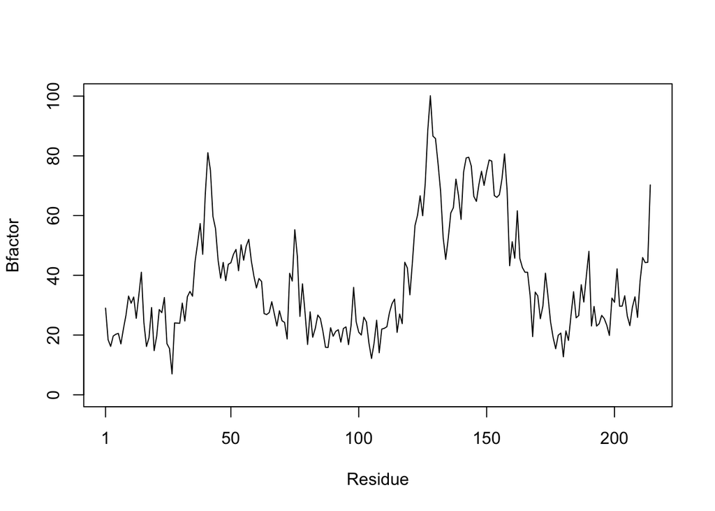

```r
plotb3(s1.b, typ = "l", ylab = "Bfactor")
```

**Q4. What would be a better plot to compare across the different proteins?** a single plot with different colored lines representing each protein’s B-factor trends which allows us to compare multiple proteins at the same time.

**Q5. Which proteins are more similar to each other in their B-factor trends. How could you quantify this?** From the clustering we can see that 1E4Y and 1AKE are the most similar ones.

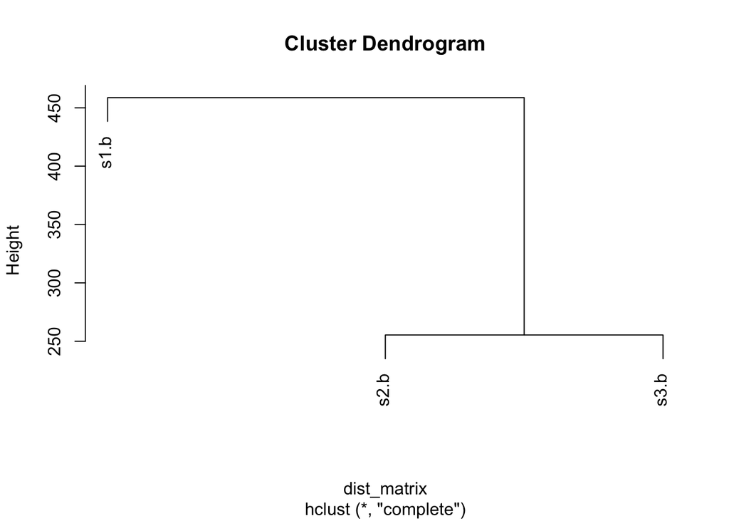

```r
bfactors <- rbind(s1.b, s2.b, s3.b)
dist_matrix <- dist(bfactors)
hclust_result <- hclust(dist_matrix)
plot(hclust_result)
```

**Q6. How would you generalize the original code above to work with any set of input protein structures?**

```r
pr_dr <- function(file, chain, elmnt, fctr) {
   plot_colors <- c("red", "blue", "green")
     for (i in 1:length(file)) {
  s1 <- read.pdb(file[i])

  s1.chain <- trim.pdb(s1, chain = chain, elety = elmnt)

  atom_df <- s1.chain$atom
   s1.fctr <- atom_df[, fctr]
     if (i == 1) {
    plotb3(s1.fctr, sse = s1.chain, typ = "l", ylab = paste(toupper(fctr), "factor", sep = ""), col = plot_colors[i])
     } else {
    lines(s1.fctr, col = plot_colors[i])
  }
     }
     legend("topright", title = "PDB File Name", file, fill = plot_colors, horiz=TRUE, cex = 0.5, inset = c(0.03, 0.06))
}
```